# Data Analysis Project: Knee Replacement Surgery Outcomes

```r
## Remove large leverages
new_data = removeInfluential(model, knee)
model_without_large_leverages = lm(KneeScore_Surgeon ~ ., data = new_data)
evaluate(model_without_large_leverages)
```

```
##                   Test       Result
## 1  Shapiro Wilk pvalue 1.780351e-08
## 2 Breusch-Pagan pvalue     0.976812
## 3            R Squared    0.2753609
## 4        Adj R Squared    0.2167679
## 5     Cross Validation     14.32084
## 6     Large Hat Values          179
```

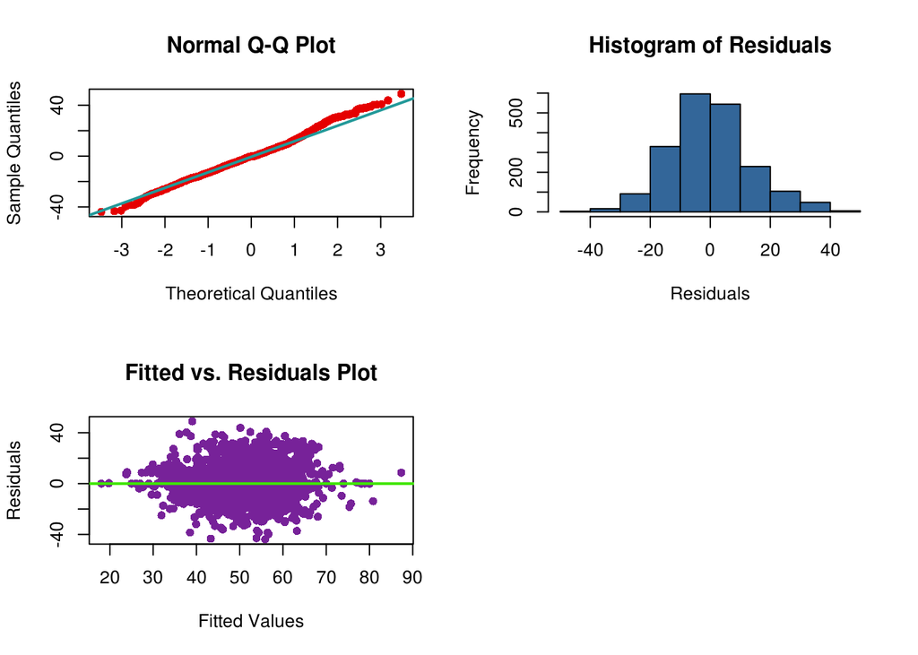

Removing the records with large hat values and refitting simply introduces more large hat values. What is unique about these rows of data?

```r
which(hatvalues(model) == 1.0)
```

```
##   17   19   74  240  244  258  354  533  638  703  763  844  876  881  891
##   17   19   74  240  244  258  354  533  638  703  763  844  876  881  891
## 1047 1093 1096 1245 1374 1406 1544 1554 1686 1775 1778 1781 1919 1927 1938
## 1047 1093 1096 1245 1374 1406 1544 1554 1686 1775 1778 1781 1919 1927 1938
```

```r
print(knee[17,])
```

```
##    Surgeon Year Age Gender Weight Height   BMI      Diagnosis  Race Side
## 17       3 2010  68 Female    148     64 25.43 Osteoarthritis White Left
##    KneeScore_Surgeon KneeScore_Patient GPS Manufacturer
## 17                48                50  No  DePuy (J&J)
##    FemoralComponentModel FemoralComponentSize FemoralComponentType
## 17             Nonporous                    2   cruciate retaining
##    TibialTrayModel TibialTraySize TibialInsertModel TibialInsertWidth
## 17       PFC Sigma            2.5         PFC Sigma                 8
##    TibialInsertType      PatellaModel PatellaDiameter
## 17           curved 3-Post Round Dome              32
```

```r
print(knee[240,])
```

```
##     Surgeon Year Age Gender Weight Height   BMI      Diagnosis  Race
## 240       3 2010  66 Female    130     68 19.78 Osteoarthritis White
##          Side KneeScore_Surgeon KneeScore_Patient GPS Manufacturer
## 240 Bilateral                60                80  No       Zimmer
##     FemoralComponentModel FemoralComponentSize FemoralComponentType
## 240        Zimmer Precoat                  E -   cruciate retaining
##     TibialTrayModel TibialTraySize TibialInsertModel TibialInsertWidth
## 240          Nexgen              4            Nexgen                10
##     TibialInsertType PatellaModel PatellaDiameter
## 240         standard       NexGen              32
```

```r
print(knee[638,])
```

```
##     Surgeon Year Age Gender Weight Height   BMI      Diagnosis  Race  Side
## 638       3 2012  67 Female    167     62 30.57 Osteoarthritis White Right
##     KneeScore_Surgeon KneeScore_Patient GPS Manufacturer
## 638                55                55 Yes  DePuy (J&J)
##     FemoralComponentModel FemoralComponentSize FemoralComponentType
## 638                 Sigma                   4N   cruciate retaining
##     TibialTrayModel TibialTraySize TibialInsertModel TibialInsertWidth
## 638       PFC Sigma              3         PFC Sigma                 8
##            TibialInsertType                 PatellaModel PatellaDiameter
## 638 high flex,Fixed bearing Triathlon Asymmetric Patella              35
```

```r
print(knee[1093,])
```

```
##      Surgeon Year Age Gender Weight Height   BMI      Diagnosis  Race
## 1093       3 2013  83 Female    130     63 23.05 Osteoarthritis White
##       Side KneeScore_Surgeon KneeScore_Patient GPS Manufacturer
## 1093 Right                66                50  No  DePuy (J&J)
##      FemoralComponentModel FemoralComponentSize FemoralComponentType
## 1093                 Sigma                    3 posterior stabilized
##      TibialTrayModel TibialTraySize TibialInsertModel TibialInsertWidth
## 1093       PFC Sigma            2.5         PFC Sigma                 8
##                 TibialInsertType            PatellaModel PatellaDiameter
## 1093 posterior stabilized,curved Oval Dome Patella 3-peg              35
```

```r
print(knee[1775, ])
```

```
##      Surgeon Year Age Gender Weight Height   BMI   Diagnosis  Race  Side
## 1775       3 2014  22   Male    240     77 28.49 Post-trauma White Right
##      KneeScore_Surgeon KneeScore_Patient GPS Manufacturer
## 1775                32                65  No       Zimmer
##      FemoralComponentModel FemoralComponentSize FemoralComponentType
## 1775               Persona                   12   cruciate retaining
##      TibialTrayModel TibialTraySize TibialInsertModel TibialInsertWidth
## 1775         Persona              H           Persona                10
##      TibialInsertType PatellaModel PatellaDiameter
## 1775    Fixed bearing      Persona              38
```

Each of these has a suspect factor entry. Perhaps the entry only occurs infrequently in the database and is causing the entire row to be flagged as high leverage? Try pulling the suspect columns out of the LM and see what happens.

```r
model_nine = lm(KneeScore_Surgeon ~ . - TibialInsertType - FemoralComponentModel - PatellaModel - TibialTrayModel - FemoralComponentType, data = knee)
evaluate(model_nine)
```

```
##                   Test       Result
## 1  Shapiro Wilk pvalue 8.105873e-08
## 2 Breusch-Pagan pvalue    0.1679994
## 3            R Squared    0.2556416
## 4        Adj R Squared    0.2141109
## 5     Cross Validation     14.34666
## 6     Large Hat Values          138
```

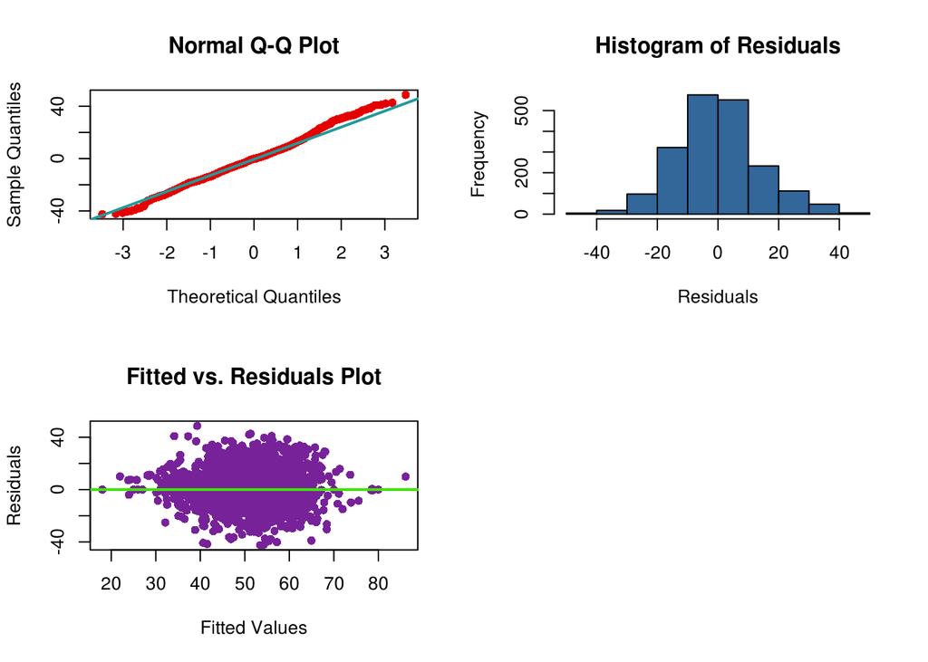